# Diari 5 - Inferència

JHJ

23/12/2024

## Qüestions abordades

*Escriviu les qüestions que heu decidit abordar.*

1. Un cop hem vist que els temps de cada algoritme *en general* no són normals, ni sembla que siguin homoscedastics. Ara ens preguntem, si els residus són normals per regions?
2. Com que són heterocedastics. Quina és la tendència dels residus?

## Comentaris

*Qualsevol cosa que vulgueu afegir sobre les qüestions.*

- Sobre la qüestió **1**, agafarem les següents regions de la variable mida: [0,250],[250,500],[500,750],[750,1000]
- Sobre la qüestió **2**, per analitzar la tendència dels residus calcularem l’arrel dels errors amb valors absolut, seguint la fórmula $\sqrt{|residus|}$, i d’aquest resultat ajustar un model com, $\sqrt{|residus|}$~$mida$.

## Variables relacionades

*Quines variables del vostre conjunt de dades, o d’altres, us sembla que caldrà considerar?*

Temps d’execució de cada algoritme i la mida del vector. I ara, ens centrarem només en els temps d’execució **amb vectors desordenats**.

També hem aplicat una transformació logarítmica dels temps d’execució de cada algoritme.

## Resultats

*Resums i gràfics obtinguts.*

**Recordatori**: En diaris anteriors vam ajustar els següents models:

```r
mods = list(
  lm.bubblesort = lm(bubblesort~mida+I(mida^2), data = simulacions),
  lm.quicksort = lm(quicksort~mida+I(mida*log(mida)), data = simulacions),
  lm.mergesort = lm(mergesort~mida+I(mida*log(mida)), data = simulacions)
)
mods.ord = list(
  lm.bubblesort = lm(ord.bubblesort~mida+I(mida^2), data = simulacions),
  lm.quicksort = lm(ord.quicksort~mida+I(mida^2), data = simulacions),
  lm.mergesort = lm(ord.mergesort~mida+I(mida*log(mida)), data = simulacions)
)
```

A partir d’aquí, treballarem sempre **amb vectors desordenats**, i podem comprovar si es compleix la hipòtesi de normalitat *en general*. Aplicant el test `shapiro.test` que doni resposta al contrast:

$$H_0: \text{Els residus són normals} \\
H_1: \text{Els residus no són normals}$$

```r
list(
  shapiro.test(residuals(mods$lm.bubblesort)),
  shapiro.test(residuals(mods$lm.quicksort)),
  shapiro.test(residuals(mods$lm.mergesort))
)
```

```
## [[1]]
##
##  Shapiro-Wilk normality test
##
## data:  residuals(mods$lm.bubblesort)
## W = 0.44261, p-value < 2.2e-16
##
##
## [[2]]
##
##  Shapiro-Wilk normality test
##
## data:  residuals(mods$lm.quicksort)
## W = 0.21194, p-value < 2.2e-16
##
##
## [[3]]
##
##  Shapiro-Wilk normality test
##
## data:  residuals(mods$lm.mergesort)
## W = 0.40461, p-value < 2.2e-16
```

En general, el p-value de cada algoritme és menor a un nivell $\alpha = 0.05$, per tant, tenim evidències en contra de la normalitat.

Ara, ens guardarem els residus de cada model/algoritme a la variable `simulacions.res`.

```r
simulacions.res = mutate(simulacions,
                         bubblesort.residus = residuals(mods$lm.bubblesort),
                         quicksort.residus = residuals(mods$lm.quicksort),
                         mergesort.residus = residuals(mods$lm.mergesort))
```

I filtrem per les regions descrites a la part dels comentaris.

```r
regions.residus = list(filter(simulacions.res, mida >= 0 & mida < 250),
                       filter(simulacions.res, mida >= 250 & mida < 500),
                       filter(simulacions.res, mida >= 500 & mida < 750),
                       filter(simulacions.res, mida >= 750 & mida <= 1000))
```

Ara podem comprovar la normalitat en cada regió, i per cada algoritme. Primer ho fem amb el bubblesort.

```r
sapply(regions.residus, function(x) shapiro.test(x$bubblesort.residus))
```

```
##           [,1]                          [,2]
## statistic 0.1609712                     0.4289292
## p.value   2.462376e-58                  1.366368e-52
## method    "Shapiro-Wilk normality test" "Shapiro-Wilk normality test"
## data.name "x$bubblesort.residus"        "x$bubblesort.residus"
##           [,3]                          [,4]
## statistic 0.4248717                     0.5423772
## p.value   1.04253e-52                   1.052134e-49
## method    "Shapiro-Wilk normality test" "Shapiro-Wilk normality test"
## data.name "x$bubblesort.residus"        "x$bubblesort.residus"
```

Amb el quicksort.

```r
sapply(regions.residus, function(x) shapiro.test(x$quicksort.residus))
```

```
##           [,1]                          [,2]
## statistic 0.2160687                     0.2521906
## p.value   3.728081e-57                  3.680305e-57
## method    "Shapiro-Wilk normality test" "Shapiro-Wilk normality test"
## data.name "x$quicksort.residus"         "x$quicksort.residus"
##           [,3]                          [,4]
## statistic 0.2006407                     0.2570318
## p.value   2.545873e-58                  7.699946e-58
## method    "Shapiro-Wilk normality test" "Shapiro-Wilk normality test"
## data.name "x$quicksort.residus"         "x$quicksort.residus"
```

Amb el mergesort.

```r
sapply(regions.residus, function(x) shapiro.test(x$mergesort.residus))
```

```
##           [,1]                          [,2]
## statistic 0.3867478                     0.3980503
## p.value   5.420979e-53                  1.813505e-53
## method    "Shapiro-Wilk normality test" "Shapiro-Wilk normality test"
## data.name "x$mergesort.residus"         "x$mergesort.residus"
##           [,3]                          [,4]
## statistic 0.4425812                     0.4124898
## p.value   3.435897e-52                  8.073519e-54
## method    "Shapiro-Wilk normality test" "Shapiro-Wilk normality test"
## data.name "x$mergesort.residus"         "x$mergesort.residus"
```

On veiem que en cap regió podem assumir normalitat dels residus, ja que el $valor-p < 0.05$. Comprovem ara si podem assumir homocedasticitat dels residus, i ho farem **en general**.

$$H_0: \text{Els residus són homocedastics} \\
H_1: \text{Els residus no són homocedastics}$$

Per responder al contrast anterior tenim el `bptest`, que funciona gracies a que hem inclós el paquet `lmtest`.

```r
bptest(mods$lm.bubblesort)
```

```
##
##  studentized Breusch-Pagan test
##
## data:  mods$lm.bubblesort
## BP = 20.846, df = 2, p-value = 2.973e-05
```

```r
bptest(mods$lm.quicksort)
```

```
##
##  studentized Breusch-Pagan test
##
## data:  mods$lm.quicksort
## BP = 37.209, df = 2, p-value = 8.32e-09
```

```r
bptest(mods$lm.mergesort)
```

```
##
##  studentized Breusch-Pagan test
##
## data:  mods$lm.mergesort
## BP = 28.513, df = 2, p-value = 6.433e-07
```

On veiem amb un $valor-p < 0.05$, tenim evidències per creure que els residus són heterocedastics, i per tant, tenen una tendència que podem visualitzar.

Un cop hem donat resposta a la qüestió **1**, ara podem respondre a la qüestió **2**, per això ens pot venir bé la següent funció que calcula l’arrel dels residus en valor absolut, *els residus seria el paràmetre x*.

```r
calcul.arrel = function(x) {
  sqrt(abs(x))
}
```

I podem visualitzar la tendència amb la següent funció, per tal de no repetir codi. *Els residus es passen per el paràmetre x*.

```r
veure.tendencia = function(x) {
  suavitza = with(simulacions.res, lowess(mida, calcul.arrel(x)))
  ggplot(data = simulacions.res) +
    geom_point(aes(x = mida, y = calcul.arrel(x)), alpha = 0.05) +
    geom_line(data = as_tibble(suavitza), aes(x=x,y=y), col = 'blue') +
    scale_x_continuous(trans = "log10") +
    scale_y_continuous(trans = "log10")
}
```

A continuació visualitzem la tendència dels residus.

#### BubbleSort *desordenat*

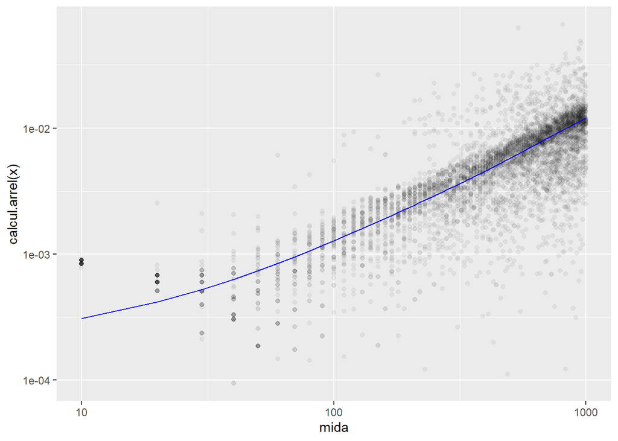

```r
veure.tendencia(simulacions.res$bubblesort.residus)
```

#### QuickSort *desordenat*

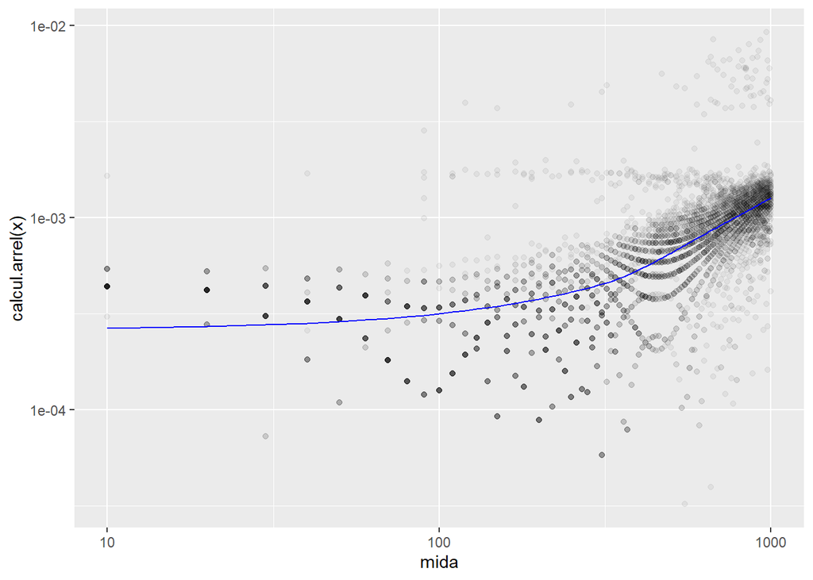

```r
veure.tendencia(simulacions.res$quicksort.residus)
```

#### MergeSort *desordenat*

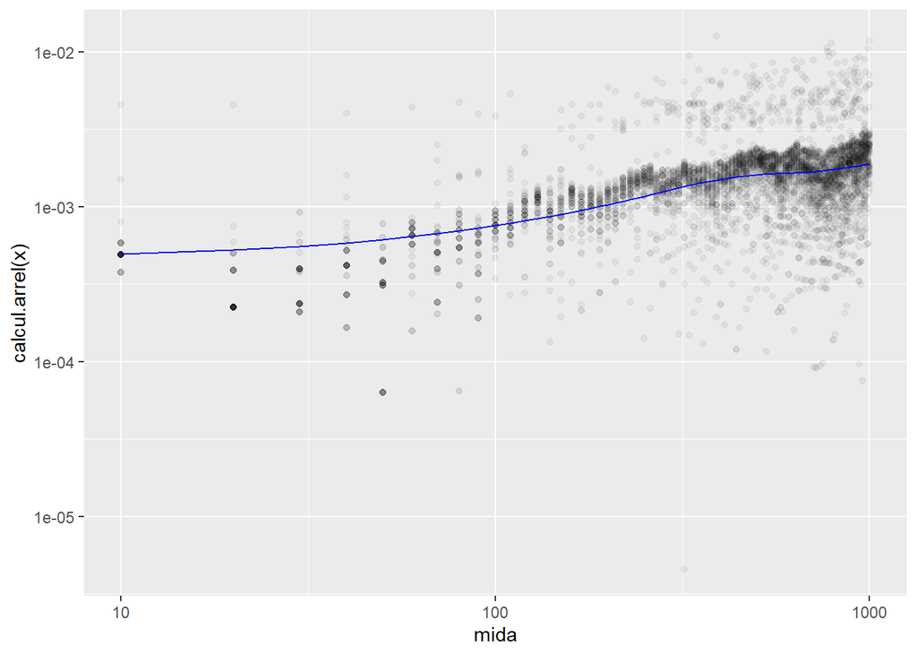

```r
veure.tendencia(simulacions.res$mergesort.residus)
```

I observant els gràfics, podem veure com el bubblesort és el que té una tendència més clara, el quicksort suavitza una mica més la recta, i el mergesort la suavitza encara més, però a prop del 0, el dos últims algoritmes semblen homocedastics, també veiem que els tres algoritmes tenen un biaix cap a la dreta, és a dir, amb vectors de mida gran, però com que no es veu molt clar, podem fer una transformació logaritmica dels temps de cada algoritme *amb vectors desordenats*, i la mida.

```r
rm(simulacions.res) # eliminem la variable simulacions.res
simulacions.res = mutate(simulacions,
                         l_mida = log(mida),
                         l_bubblesort = log(bubblesort),
                         l_quicksort = log(quicksort),
                         l_mergesort = log(mergesort))
```

I ara tornem a ajustar nous models, pero ara amb el logaritme dels temps i la mida.

```r
mods.log = list(
  lm.bubblesort = lm(l_bubblesort~l_mida+I(l_mida^2), data = simulacions.res),
  lm.quicksort = lm(l_quicksort~l_mida+I(l_mida*log(l_mida)), data = simulacions.res),
  lm.mergesort = lm(l_mergesort~l_mida+I(l_mida*log(l_mida)), data = simulacions.res)
)
```

Ara tornem a comprovar la hipòtesi de normalitat.

$$H_0: \text{Els residus són normals} \\
H_1: \text{Els residus no són normals}$$

```r
list(
  shapiro.test(residuals(mods.log$lm.bubblesort)),
  shapiro.test(residuals(mods.log$lm.quicksort)),
  shapiro.test(residuals(mods.log$lm.mergesort))
)
```

```
## [[1]]
##
##  Shapiro-Wilk normality test
##
## data:  residuals(mods.log$lm.bubblesort)
## W = 0.46104, p-value < 2.2e-16
##
##
## [[2]]
##
##  Shapiro-Wilk normality test
##
## data:  residuals(mods.log$lm.quicksort)
## W = 0.37467, p-value < 2.2e-16
##
##
## [[3]]
##
##  Shapiro-Wilk normality test
##
## data:  residuals(mods.log$lm.mergesort)
## W = 0.45389, p-value < 2.2e-16
```

On veiem que ara *en general*, el p-value de cada algoritme segueix sent menor a un nivell $\alpha = 0.05$, per tant, tenim evidències en contra de la normalitat.

Ens guardem els residus de cada model/algoritme.

```r
simulacions.res = mutate(simulacions.res,
                         bubblesort.residus = residuals(mods.log$lm.bubblesort),
                         quicksort.residus = residuals(mods.log$lm.quicksort),
                         mergesort.residus = residuals(mods.log$lm.mergesort))
```

I filtrem per les regions descrites als comentaris.

```r
regions.residus = list(filter(simulacions.res, mida >= 0 & mida < 250),
                       filter(simulacions.res, mida >= 250 & mida < 500),
                       filter(simulacions.res, mida >= 500 & mida < 750),
                       filter(simulacions.res, mida >= 750 & mida <= 1000))
```

I comprovem la normalitat en cada regió, i per cada algoritme. Primer ho fem amb el bubblesort.

```r
sapply(regions.residus, function(x) shapiro.test(x$bubblesort.residus))
```

```
##           [,1]                          [,2]
## statistic 0.3973843                     0.4412748
## p.value   1.058018e-52                  3.143159e-52
## method    "Shapiro-Wilk normality test" "Shapiro-Wilk normality test"
## data.name "x$bubblesort.residus"        "x$bubblesort.residus"
##           [,3]                          [,4]
## statistic 0.5119073                     0.6174419
## p.value   5.082148e-50                  7.393506e-47
## method    "Shapiro-Wilk normality test" "Shapiro-Wilk normality test"
## data.name "x$bubblesort.residus"        "x$bubblesort.residus"
```

Amb el quicksort.

```r
sapply(regions.residus, function(x) shapiro.test(x$quicksort.residus))
```

```
##           [,1]                          [,2]
## statistic 0.4391948                     0.3810965
## p.value   1.61946e-51                   6.207414e-54
## method    "Shapiro-Wilk normality test" "Shapiro-Wilk normality test"
## data.name "x$quicksort.residus"         "x$quicksort.residus"
##           [,3]                          [,4]
## statistic 0.3201896                     0.3375101
## p.value   1.599606e-55                  7.389954e-56
## method    "Shapiro-Wilk normality test" "Shapiro-Wilk normality test"
## data.name "x$quicksort.residus"         "x$quicksort.residus"
```

Amb el mergesort.

```r
sapply(regions.residus, function(x) shapiro.test(x$mergesort.residus))
```

```
##           [,1]                          [,2]
## statistic 0.3674968                     0.5184466
## p.value   1.65585e-53                   8.39014e-50
## method    "Shapiro-Wilk normality test" "Shapiro-Wilk normality test"
## data.name "x$mergesort.residus"         "x$mergesort.residus"
##           [,3]                          [,4]
## statistic 0.5245582                     0.4966354
## p.value   1.34736e-49                   2.971121e-51
## method    "Shapiro-Wilk normality test" "Shapiro-Wilk normality test"
## data.name "x$mergesort.residus"         "x$mergesort.residus"
```

On veiem que totes les regions segueixen rebutjant la normalitat dels residus. Comprovem ara si podem assumir homocedasticitat.

$$H_0: \text{Els residus són homocedastics} \\
H_1: \text{Els residus no són homocedastics}$$

```r
bptest(mods.log$lm.bubblesort)
```

```
##
##  studentized Breusch-Pagan test
##
## data:  mods.log$lm.bubblesort
## BP = 15.05, df = 2, p-value = 0.0005394
```

```r
bptest(mods.log$lm.quicksort)
```

```
##
##  studentized Breusch-Pagan test
##
## data:  mods.log$lm.quicksort
## BP = 80.38, df = 2, p-value < 2.2e-16
```

```r
bptest(mods.log$lm.mergesort)
```

```
##
##  studentized Breusch-Pagan test
##
## data:  mods.log$lm.mergesort
## BP = 60.152, df = 2, p-value = 8.671e-14
```

I veiem que continuen sent molt heterocedastics.

Si ara provem a visualitzar la tendència dels residus mitjançant la funció `veure.tendencia`, obtenim.

#### BubbleSort *desordenat*

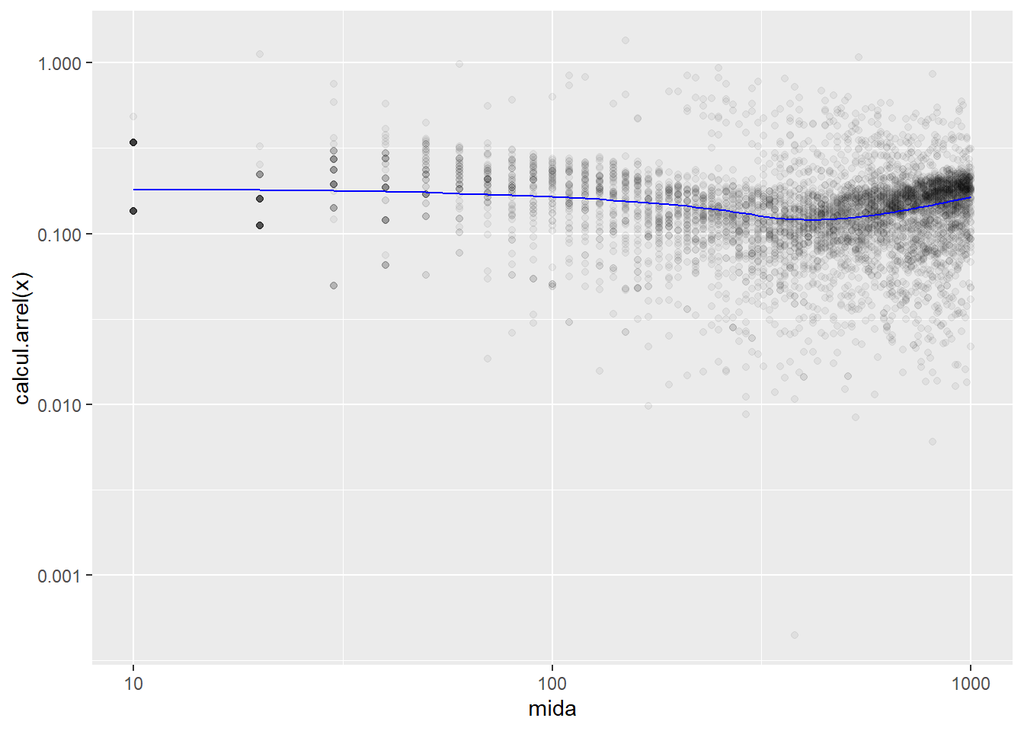

```r
veure.tendencia(simulacions.res$bubblesort.residus)
```

#### QuickSort *desordenat*

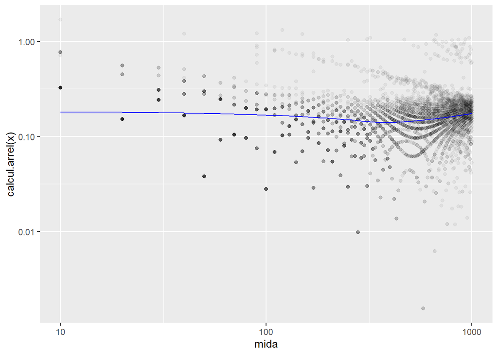

```r
veure.tendencia(simulacions.res$quicksort.residus)
```

#### MergeSort *desordenat*

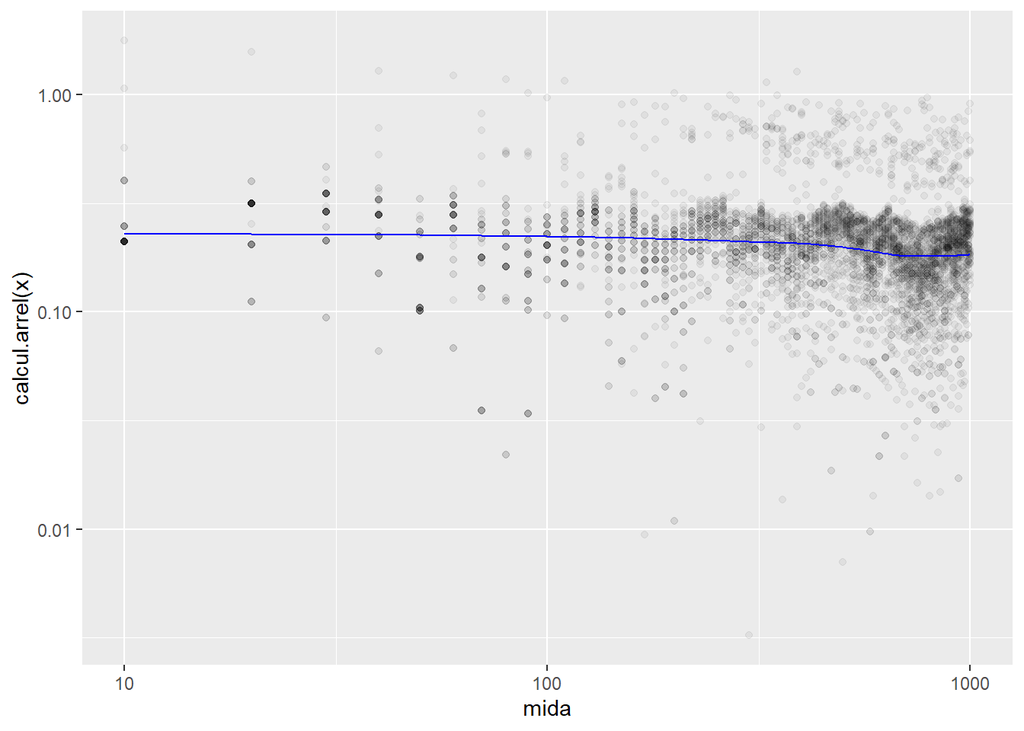

```r
veure.tendencia(simulacions.res$mergesort.residus)
```

I observant els gràfics, ara podem veure, que els residus ara semblen bastant homocedastics amb un biaix important cap a la dreta.

Conclusió, els residus no segueixen una normal, però els podem aproximar a una normal amb biaix cap a la dreta, és a dir, a una distribució **skew normal**. Per el següent pas, ens pot ajudar dividir les dades en dos regions: [0-500],[500-1000].

```r
regions.residus = list(filter(simulacions.res, mida >= 0 & mida < 500),
                       filter(simulacions.res, mida >= 500 & mida <= 1000))
```

I també ens pot ser útil definir la següent funció.

```r
histograma = function(residus) {
  ggplot() +
    geom_histogram(aes(x = residus, y = after_stat(density))) +
    geom_function(aes(col = 'Skew Normal(alpha = -4)'), linewidth = 1,
                  fun = function(x) dsn(x, xi = mean(residus), omega = sd(residus), -4)) +
    geom_function(aes(col = 'Skew Normal(alpha = -1)'), linewidth = 1,
                  fun = function(x) dsn(x, xi = mean(residus), omega = sd(residus), -1)) +
    geom_function(aes(col = 'Skew Normal(alpha = 0)'), linewidth = 1,
                  fun = function(x) dsn(x, xi = mean(residus), omega = sd(residus), 0)) +
    geom_function(aes(col = 'Skew Normal(alpha = 1)'), linewidth = 1,
                  fun = function(x) dsn(x, xi = mean(residus), omega = sd(residus), 1)) +
    geom_function(aes(col = 'Skew Normal(alpha = 4)'), linewidth = 1,
                  fun = function(x) dsn(x, xi = mean(residus), omega = sd(residus), 4))
}
```

I ja podem visualitzar si els residus de cada model es poden ajustar a una distribució skew normal *o normal amb biaix*. Primer mostrem amb vectors petits.

#### BubbleSort *desordenat*

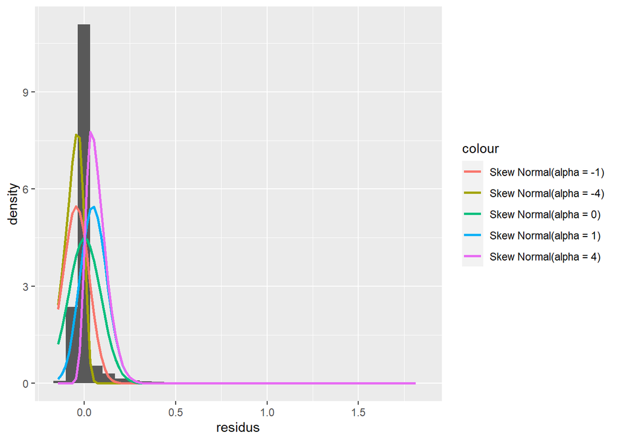

```r
histograma(regions.residus[[1]]$bubblesort.residus)
```

#### QuickSort *desordenat*

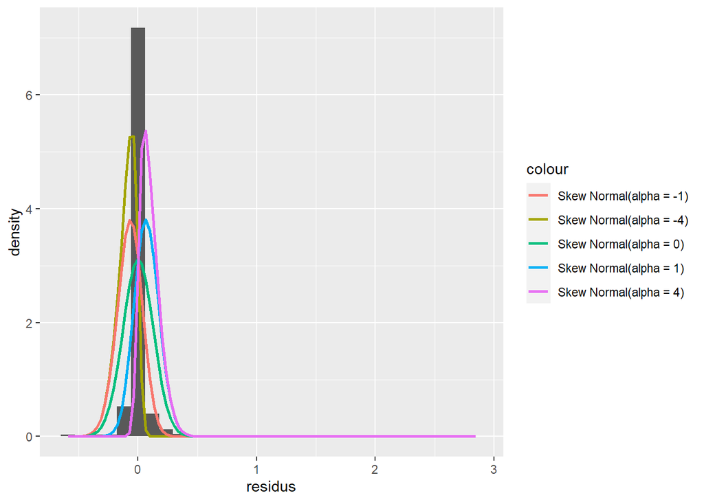

```r
histograma(regions.residus[[1]]$quicksort.residus)
```

#### MergeSort *desordenat*

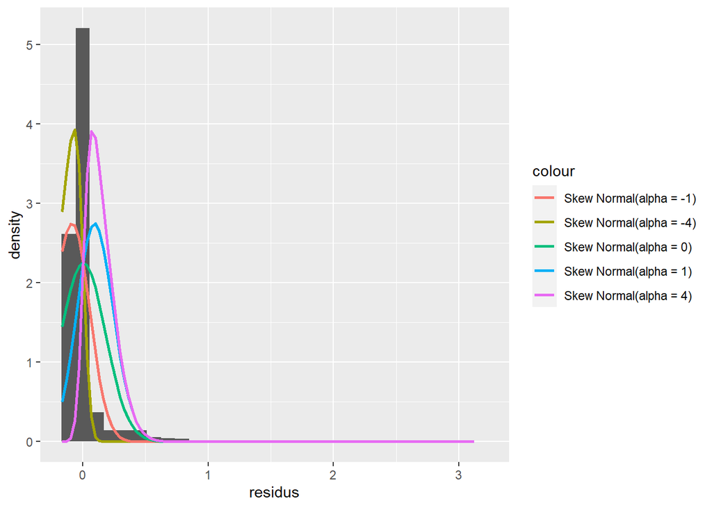

```r
histograma(regions.residus[[1]]$mergesort.residus)
```

I amb vectors grans.

#### BubbleSort *desordenat*

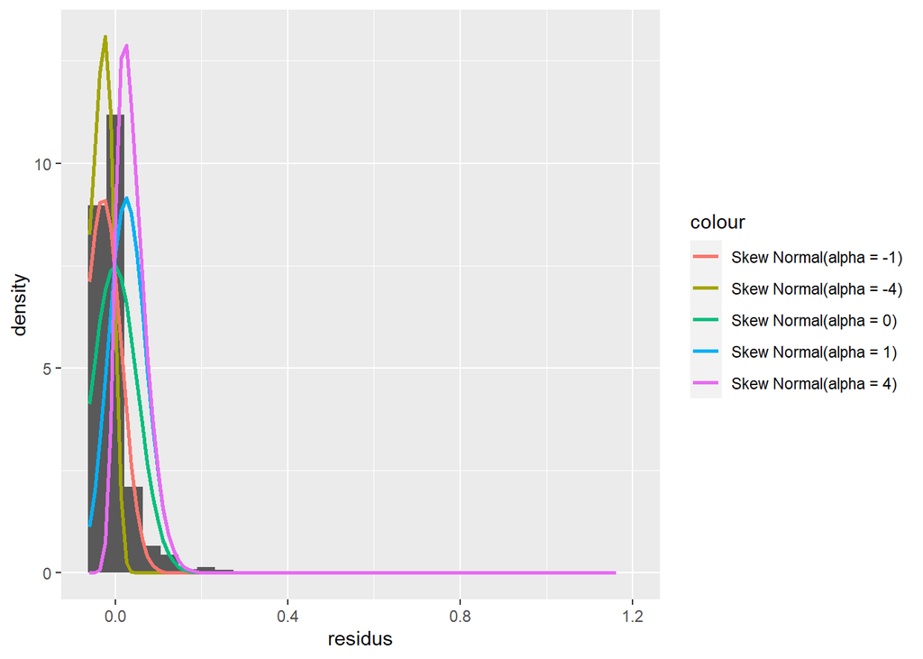

```r
histograma(regions.residus[[2]]$bubblesort.residus)
```

#### QuickSort *desordenat*

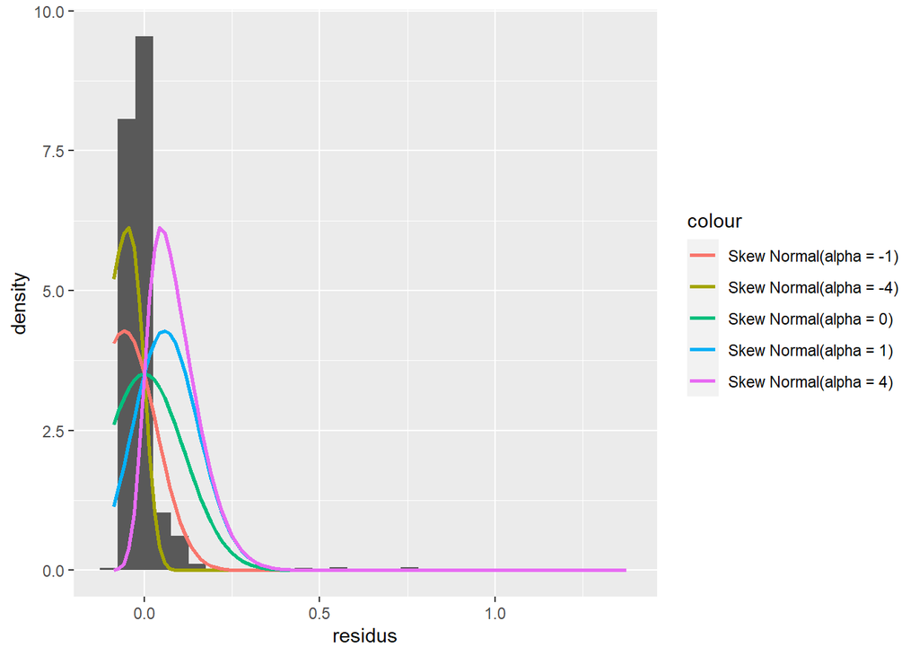

```r
histograma(regions.residus[[2]]$quicksort.residus)
```

#### MergeSort *desordenat*

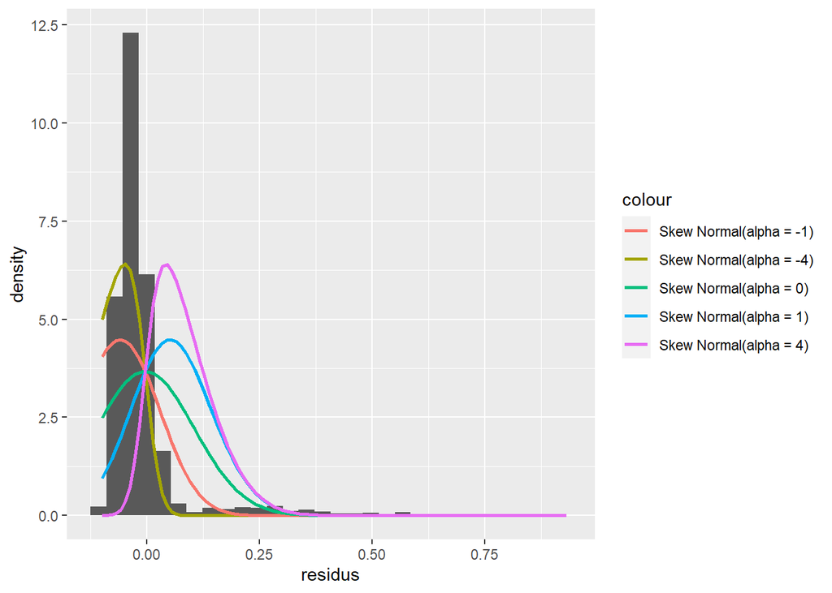

```r
histograma(regions.residus[[2]]$mergesort.residus)
```

On veiem que els residus semblen seguir una skew normal amb un $\alpha \in \{-4,-1,4\}$, que serien els valors que ajusten millor els residus.

Considerant els últims models ajustats.

```r
mods.log
```

```
## $lm.bubblesort
##
## Call:
## lm(formula = l_bubblesort ~ l_mida + I(l_mida^2), data = simulacions.res)
##
## Coefficients:
## (Intercept)       l_mida  I(l_mida^2)
##   -18.41690      1.81147      0.01733
##
##
## $lm.quicksort
##
## Call:
## lm(formula = l_quicksort ~ l_mida + I(l_mida * log(l_mida)),
##     data = simulacions.res)
##
## Coefficients:
##             (Intercept)                   l_mida  I(l_mida * log(l_mida))
##               -18.37137                  1.26795                 -0.04135
##
##
## $lm.mergesort
##
## Call:
## lm(formula = l_mergesort ~ l_mida + I(l_mida * log(l_mida)),
##     data = simulacions.res)
##
## Coefficients:
##             (Intercept)                   l_mida  I(l_mida * log(l_mida))
##               -15.99327                  0.86315                  0.06736
```

Hem vist que podem ajustar els errors a una skew normal amb $\alpha = \pm 4$, ara per acabar, podem comprovar la significació dels nostres models com.

Primer ajustem els models següents:

```r
mods.arrel = list(
  lm.bubblesort = lm(calcul.arrel(bubblesort.residus)~mida, data = simulacions.res),
  lm.quicksort = lm(calcul.arrel(quicksort.residus)~mida, data = simulacions.res),
  lm.mergesort = lm(calcul.arrel(mergesort.residus)~mida, data = simulacions.res)
)
mods.arrel
```

```
## $lm.bubblesort
##
## Call:
## lm(formula = calcul.arrel(bubblesort.residus) ~ mida, data = simulacions.res)
##
## Coefficients:
## (Intercept)         mida
##    1.65e-01    -2.14e-05
##
##
## $lm.quicksort
##
## Call:
## lm(formula = calcul.arrel(quicksort.residus) ~ mida, data = simulacions.res)
##
## Coefficients:
## (Intercept)         mida
##   0.1814532   -0.0000137
##
##
## $lm.mergesort
##
## Call:
## lm(formula = calcul.arrel(mergesort.residus) ~ mida, data = simulacions.res)
##
## Coefficients:
## (Intercept)         mida
##   2.546e-01   -5.998e-05
```

I comprovem el següent contrast de significació:

$$\beta_j = 0 \\
\beta_j \neq 0$$

Per respondre al contrast, podem fer servir la funció `summary()`. Amb els primers models ajustats.

```r
summary(mods.log$lm.bubblesort)
```

```
##
## Call:
## lm(formula = l_bubblesort ~ l_mida + I(l_mida^2), data = simulacions.res)
##
## Residuals:
##      Min       1Q   Median       3Q      Max
## -0.14203 -0.02665 -0.01265  0.00523  1.81402
##
## Coefficients:
##               Estimate Std. Error t value Pr(>|t|)
## (Intercept) -1.842e+01  2.308e-02 -797.85   <2e-16 ***
## l_mida       1.811e+00  8.951e-03  202.37   <2e-16 ***
## I(l_mida^2)  1.733e-02  8.488e-04   20.42   <2e-16 ***
## ---
## Signif. codes:  0 '***' 0.001 '**' 0.01 '*' 0.05 '.' 0.1 ' ' 1
##
## Residual standard error: 0.07302 on 4997 degrees of freedom
## Multiple R-squared:  0.9984, Adjusted R-squared:  0.9984
## F-statistic: 1.588e+06 on 2 and 4997 DF,  p-value: < 2.2e-16
```

```r
summary(mods.log$lm.quicksort)
```

```
##
## Call:
## lm(formula = l_quicksort ~ l_mida + I(l_mida * log(l_mida)),
##     data = simulacions.res)
##
## Residuals:
##      Min       1Q   Median       3Q      Max
## -0.58688 -0.03349 -0.01770  0.00056  2.84711
##
## Coefficients:
##                          Estimate Std. Error  t value Pr(>|t|)
## (Intercept)             -18.37137    0.06684 -274.874  < 2e-16 ***
## l_mida                    1.26795    0.03492   36.311  < 2e-16 ***
## I(l_mida * log(l_mida))  -0.04135    0.01324   -3.122  0.00181 **
## ---
## Signif. codes:  0 '***' 0.001 '**' 0.01 '*' 0.05 '.' 0.1 ' ' 1
##
## Residual standard error: 0.1208 on 4997 degrees of freedom
## Multiple R-squared:  0.9874, Adjusted R-squared:  0.9874
## F-statistic: 1.963e+05 on 2 and 4997 DF,  p-value: < 2.2e-16
```

```r
summary(mods.log$lm.mergesort)
```

```
##
## Call:
## lm(formula = l_mergesort ~ l_mida + I(l_mida * log(l_mida)),
##     data = simulacions.res)
##
## Residuals:
##      Min       1Q   Median       3Q      Max
## -0.16299 -0.05469 -0.03343 -0.00589  3.12430
##
## Coefficients:
##                          Estimate Std. Error t value Pr(>|t|)
## (Intercept)             -15.99327    0.08094 -197.59  < 2e-16 ***
## l_mida                    0.86315    0.04229   20.41  < 2e-16 ***
## I(l_mida * log(l_mida))   0.06736    0.01604    4.20 2.72e-05 ***
## ---
## Signif. codes:  0 '***' 0.001 '**' 0.01 '*' 0.05 '.' 0.1 ' ' 1
##
## Residual standard error: 0.1463 on 4997 degrees of freedom
## Multiple R-squared:  0.9774, Adjusted R-squared:  0.9773
## F-statistic: 1.079e+05 on 2 and 4997 DF,  p-value: < 2.2e-16
```

I amb els models que ajusten l’arrel dels errors dels models anteriors **en valor absolut** amb la mida.

```r
summary(mods.arrel$lm.bubblesort)
```

```
##
## Call:
## lm(formula = calcul.arrel(bubblesort.residus) ~ mida, data = simulacions.res)
##
## Residuals:
##      Min       1Q   Median       3Q      Max
## -0.15646 -0.05473 -0.01189  0.03096  1.18503
##
## Coefficients:
##               Estimate Std. Error t value Pr(>|t|)
## (Intercept)  1.650e-01  2.703e-03  61.048  < 2e-16 ***
## mida        -2.140e-05  4.648e-06  -4.605 4.23e-06 ***
## ---
## Signif. codes:  0 '***' 0.001 '**' 0.01 '*' 0.05 '.' 0.1 ' ' 1
##
## Residual standard error: 0.09487 on 4998 degrees of freedom
## Multiple R-squared:  0.004225,   Adjusted R-squared:  0.004026
## F-statistic: 21.21 on 1 and 4998 DF,  p-value: 4.228e-06
```

```r
summary(mods.arrel$lm.quicksort)
```

```
##
## Call:
## lm(formula = calcul.arrel(quicksort.residus) ~ mida, data = simulacions.res)
##
## Residuals:
##      Min       1Q   Median       3Q      Max
## -0.17197 -0.06469 -0.01592  0.02884  1.50602
##
## Coefficients:
##               Estimate Std. Error t value Pr(>|t|)
## (Intercept)  1.815e-01  3.484e-03  52.081   <2e-16 ***
## mida        -1.370e-05  5.990e-06  -2.287   0.0222 *
## ---
## Signif. codes:  0 '***' 0.001 '**' 0.01 '*' 0.05 '.' 0.1 ' ' 1
##
## Residual standard error: 0.1223 on 4998 degrees of freedom
## Multiple R-squared:  0.001045,   Adjusted R-squared:  0.0008454
## F-statistic:  5.23 on 1 and 4998 DF,  p-value: 0.02225
```

```r
summary(mods.arrel$lm.mergesort)
```

```
##
## Call:
## lm(formula = calcul.arrel(mergesort.residus) ~ mida, data = simulacions.res)
##
## Residuals:
##      Min       1Q   Median       3Q      Max
## -0.23501 -0.06925 -0.01867  0.02945  1.51354
##
## Coefficients:
##               Estimate Std. Error t value Pr(>|t|)
## (Intercept)  2.546e-01  3.880e-03  65.623   <2e-16 ***
## mida        -5.998e-05  6.671e-06  -8.991   <2e-16 ***
## ---
## Signif. codes:  0 '***' 0.001 '**' 0.01 '*' 0.05 '.' 0.1 ' ' 1
##
## Residual standard error: 0.1362 on 4998 degrees of freedom
## Multiple R-squared:  0.01592,    Adjusted R-squared:  0.01572
## F-statistic: 80.84 on 1 and 4998 DF,  p-value: < 2.2e-16
```

I finalment, veiem que els diferents valor-p són menor a un $\alpha = 0.05$, i per tant, tenim evidències en contra de la hipotesi nul·la. Per tant, podem assumir que totes les variables són diferent de 0.

```r
algoritmes
```

```
## # A tibble: 3 × 3
##   algoritme  estable implementacio.recursiva
##   <chr>      <lgl>   <lgl>
## 1 bubblesort TRUE    FALSE
## 2 quicksort  FALSE   TRUE
## 3 mergesort  TRUE    TRUE
```

Veiem que els algoritmes que tenen una implementació recursiva, són els que també semblaven més homocedastics, *tot i no ser-ho finalment*. Aixó és pel fet que quicksort i mergesort s’implementen recursivament perqué la seva implementació indica que són algoritmes de divideix i venç, si mirem com estan implementats els algoritmes, veiem que quicksort i mergesort segueixen l’esquema següent *extret dels apunts del tema 7 de EDA d’en Joan Surrell*:

```
ESQUEMA DiV(Entrada) RETORNA Res:Sortida
  Solucio: TAULA [1..n] DE Sortida

  SI Entrada Simple LLAVORS
    Res:= Solucio Simple
  ALTRAMENT
    PER Totes les Parts FER
      Solucioi:= DiV(Parti(Entrada))
    FPER
    Res:= Compondre(Entrada, Solucio)
  FSI
  RETORNA(Res)
FESQUEMA
```

- El **quicksort** també se li diu **ordenació ràida**, i és el mètode més ràpid que existeix en la major part dels casos, a més, també és senzill.
- El **mergesort** també se li diu **ordenació per fusió**, no és tan senzill, però és més estable que el quicksort, **també en el cas pitjor**.

## Noves qüestions

*Dubtes, preguntes i qüestions que han sorgit durant l’estudi.*

Com es poden ajustar els temps d’execució a una skew normal? És a dir, és pot fer de la manera següent:

```r
lm(l_bubblesort~l_mida+dsn(l_bubblesort, xi = mean(l_bubblesort), omega = sd(l_bubblesort), alpha = -4), data = simulacions.res)
```

```
##
## Call:
## lm(formula = l_bubblesort ~ l_mida + dsn(l_bubblesort, xi = mean(l_bubblesort),
##     omega = sd(l_bubblesort), alpha = -4), data = simulacions.res)
##
## Coefficients:
##                                                                      (Intercept)
##                                                                         -18.8207
##                                                                           l_mida
##                                                                           1.9869
## dsn(l_bubblesort, xi = mean(l_bubblesort), omega = sd(l_bubblesort), alpha = -4)
##                                                                          -0.1087
```

## Material addicional

*Opcional, si heu consultat alguna web o font. Indiqueu els enllaços.*

[skewnormal_wikipedia](https://en.wikipedia.org/wiki/Skew_normal_distribution)

[skewnormal1](https://www.rdocumentation.org/packages/EvidenceSynthesis/versions/0.5.0/topics/skewNormal)

[skewnormal2](https://search.r-project.org/CRAN/refmans/sn/html/dsn.html)

## Llista de tasques

*Opcional, si us va bé anar indicant les feines que cal fer i com les penseu repartir entre els membres de l’equip.*